# MK Praktikum Unggulan Universitas Gunadarma

## Relationship Between Variables

- Kita dapat mengatakan bahwa dua variabel memiliki hubungan apabila perubahan pada salah satu variabel berkaitan dengan perubahan pada variabel lainnya.
- Contoh: Harga dan jarak perjalanan taksi. Semakin jauh jarak perjalanan, biasanya semakin tinggi harga yang harus dibayar. Oleh karena itu, harga dan jarak memiliki hubungan positif.
- Salah satu cara termudah untuk melihat hubungan antara dua variabel adalah menggunakan scatter plot.

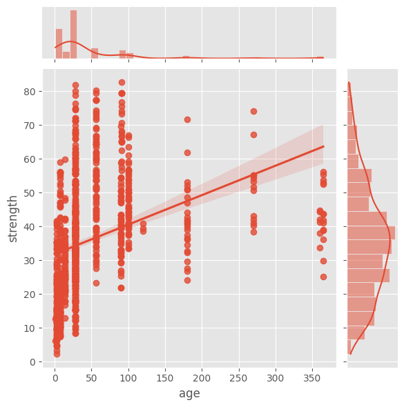

```python
# Tampilkan hubungan antara data kolom 'age' dan 'strength'
plt.figure(figsize = (8,6))
sns.jointplot(x = 'age', y = 'strength', data = data, kind = 'reg')
plt.show()
```

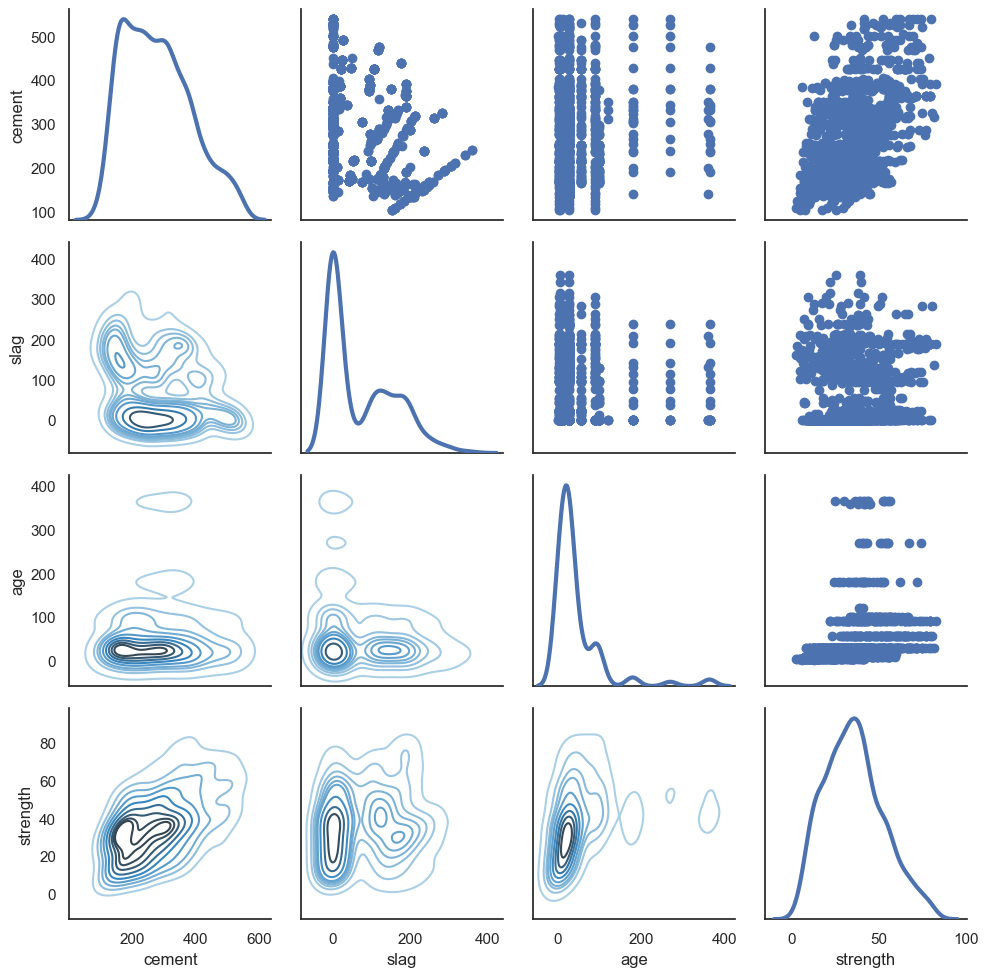

```python
# Tampilkan hubungan antara data kolom 'cement', 'slag','age' dan 'strength'
sns.set(style = "white")
df = data.loc[:,['cement','slag','age','strength']]
g = sns.PairGrid(df, diag_sharey = False)
g.map_lower(sns.kdeplot, cmap = 'Blues_d')
g.map_upper(plt.scatter)
g.map_diag(sns.kdeplot, lw = 3)
plt.show()
```

## Correlation

- Correlation (korelasi) adalah ukuran yang menunjukkan arah dan kekuatan hubungan antara dua variabel.
- Nilai korelasi berada antara -1 hingga 1:
  - Mendekati 1 → hubungan positif yang kuat.
  - Mendekati -1 → hubungan negatif yang kuat.
  - Mendekati 0 → tidak terdapat hubungan linear yang kuat.

Perlu diingat bahwa korelasi tidak selalu berarti hubungan sebab-akibat (causation).

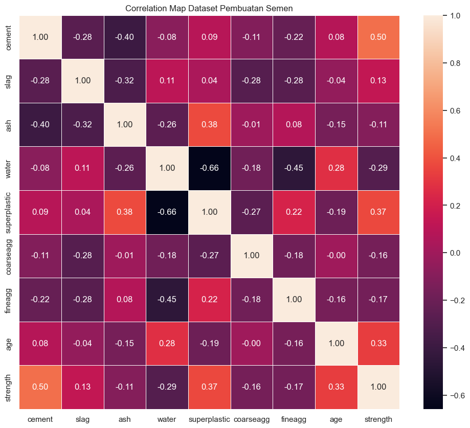

```python
# Buatlah diagram heatmap dari setiap kolom yang ada dengan library seaborn
plt.figure(figsize = (12,10))
sns.heatmap(data.corr(numeric_only = True), annot = True, linewidths = 0.5, fmt = '.2f')
plt.title('Correlation Map Dataset Pembuatan Semen')
plt.show()
```

## Covariance

- Covariance (kovarians) adalah ukuran yang menunjukkan kecenderungan dua variabel untuk berubah secara bersama-sama.
- Kovarians membantu kita mengetahui arah hubungan antara dua variabel:
  - Kovarians positif → ketika satu variabel meningkat, variabel lainnya cenderung ikut meningkat.
  - Kovarians negatif → ketika satu variabel meningkat, variabel lainnya cenderung menurun.
  - Kovarians mendekati nol → tidak terdapat hubungan linear yang jelas antara kedua variabel.

Dalam konteks vektor, kovarians dapat bernilai positif ketika kedua variabel cenderung bergerak ke arah yang sama dan negatif ketika bergerak ke arah yang berlawanan. Namun, istilah ortogonal lebih tepat digunakan untuk menjelaskan dot product atau hubungan geometris antarvektor, bukan sebagai definisi utama kovarians.

```python
# Bandingkan nilai covariance diantara kolom 'strength' dengan kolom 'age' dan kolom 'cement'
np.cov(data.strength, data.age)
print("Covariance strength dan age: ", data.strength.cov(data.age))
print("Covariance strength dan cement: ", data.strength.cov(data.cement))
```

```
Covariance strength dan age:  347.0597575174315
Covariance strength dan cement:  869.1430218800418
```

## Pearson Correlation

- Pearson correlation (korelasi Pearson) adalah ukuran yang digunakan untuk mengetahui arah dan kekuatan hubungan linear antara dua variabel.
- Korelasi Pearson dapat dihitung dengan membagi covariance antara dua variabel dengan hasil kali standar deviasi masing-masing variabel. $$ \text{Pearson correlation} = \frac{\operatorname{Cov}(A,B)}{\operatorname{Std}(A) \times \operatorname{Std}(B)} $$
- Nilai korelasi Pearson berada antara -1 hingga 1:
  - Mendekati 1 → hubungan positif yang sangat kuat.
  - Mendekati -1 → hubungan negatif yang sangat kuat.
  - Mendekati 0 → hubungan linear yang lemah atau tidak ada.

```python
# Hitung nilai pearson correlation dari kolom 'cement' dan 'age'
p1 = data.loc[:,['cement','age']].corr(method = 'pearson')
p2 = data.cement.cov(data.age) / (data.cement.std() * data.age.std())
print('Pearson correlation dengan metode .corr():')
print(p1)
print('Pearson correlation dengan definisi manual: ', p2)
```

```
Pearson correlation dengan metode .corr():
          cement       age
cement  1.000000  0.081946
age     0.081946  1.000000
Pearson correlation dengan definisi manual:  0.08194602387182237
```

## Spearman's Rank Correlation

- Spearman's Rank Correlation (korelasi peringkat Spearman) adalah metode untuk mengukur arah dan kekuatan hubungan antara dua variabel berdasarkan peringkat (rank) datanya.
- Korelasi Pearson bekerja dengan baik ketika hubungan antara dua variabel bersifat linear. Namun, Pearson cukup sensitif terhadap outlier, sehingga adanya nilai pencilan dapat memengaruhi hasil korelasi.
- Korelasi Spearman menggunakan peringkat setiap nilai, sehingga lebih tahan terhadap pengaruh outlier dibandingkan korelasi Pearson.

```python
# Hitung nilai spearsman rank dari kolom data 'age' dan 'strength'
s1 = data.loc[:,['age','strength']].corr(method = 'spearman')
ranked_data = data.rank()
s2 = ranked_data.loc[:,['age','strength']].corr(method = 'pearson')
print("Spearman's rank correlation:")
print(s1)
print("Spearman's correlation dengan teknik peringkat (rank):")
print(s2)
```

```
Spearman's rank correlation:
               age  strength
age       1.000000  0.596028
strength  0.596028  1.000000
Spearman's correlation dengan teknik peringkat (rank):
               age  strength
age       1.000000  0.596028
strength  0.596028  1.000000
```

## Hypothesis Testing

- Pengujian hipotesis digunakan untuk menentukan apakah suatu efek atau hubungan yang terlihat pada sampel cukup kuat untuk dianggap sebagai bukti adanya hubungan pada populasi.
- Langkah pertama adalah mengukur ukuran efek nyata dengan memilih statistik uji. Pilihan alami untuk statistik uji adalah perbedaan mean atau rata-rata antara dua kelompok.
- Langkah kedua adalah mendefinisikan hipotesis nol yaitu model sistem berdasarkan asumsi bahwa efek yang tampak tidak nyata. Hipotesis nol adalah jenis hipotesis yang digunakan dalam statistik yang menyatakan bahwa tidak ada signifikansi statistik dalam serangkaian pengamatan yang diberikan. Hipotesis nol adalah hipotesis yang orang mencoba untuk menyangkalnya. Hipotesis alternatif adalah hipotesis yang orang ingin mencoba untuk membuktikannya.
- Langkah ketiga adalah menghitung p-value yaitu probabilitas melihat efek nyata jika hipotesis nol benar. Misalkan kita memiliki uji hipotesis nol. Kemudian kita hitung nilai p. Jika nilai p kurang dari atau sama dengan ambang batas, kami menolak hipotesis nol.
- Jika p-value rendah, pengaruh tersebut dikatakan signifikan secara statistik artinya tidak mungkin terjadi secara kebetulan. Oleh karena itu kita dapat mengatakan bahwa efeknya lebih mungkin muncul pada populasi yang lebih besar.
- Contoh: Diketahui bahwa:
  - Hipotesis nol: dunia rata.
  - Hipotesis alternatif: dunia itu bulat.

  Beberapa ilmuwan mulai menyangkal hipotesis nol. Ini akhirnya mengarah pada refleksi hipotesis nol dan penerimaan hipotesis alternatif.

  Jika nilai p rendah, kami menyimpulkan bahwa hipotesis nol tidak mungkin benar.
- Contoh berdasarkan data pada pertemuan sebelumnya:
  - Saya ingin mengetahui apakah rata-rata radius dan rata-rata area terkait satu sama lain? Hipotesis nol saya adalah bahwa "hubungan antara rata-rata radius dan rata-rata area adalah nol pada populasi tumor".
  - Sekarang kita perlu menyangkal hipotesis nol ini menggunakan p-value untuk menunjukkan bahwa rata-rata radius dan rata-rata area berhubungan (walaupun sebenarnya kita telah mengetahui hasilnya berdasarkan analisa korelasi yang telah dilakukan sebelumnya).

```python
# Lakukan hubungan hipotesis data antara kolom 'age' dan 'strength'
# Hipotesis nol (H0): tidak ada hubungan antara umur beton dan kekuatan tekannya
# Hipotesis alternatif (H1): ada hubungan antara umur beton dan kekuatan tekannya
statistic, p_value = stats.ttest_rel(data.age, data.strength)
print('Statistik uji:', statistic)
print('p-value adalah: ', p_value)
print('Tingkat signifikansi: ', 0.05)
if p_value < 0.05:
    print('Kesimpulan: menolak hipotesis nol, terdapat hubungan signifikan antara umur dan kekuatan beton')
else:
    print('Kesimpulan: tidak menolak hipotesis nol, tidak terdapat hubungan signifikan')
```

```
Statistik uji: 5.283669054951027
p-value adalah:  1.545311719208924e-07
Tingkat signifikansi:  0.05
Kesimpulan: menolak hipotesis nol, terdapat hubungan signifikan antara umur dan kekuatan beton
```

**Perhatian!** Konversi file IPYNB menjadi PDF untuk melakukan pengumpulan tugas di V-Class. [[VIDEO]](https://youtu.be/qXELXtnAK7c)

Copyright © Pengelola MK Praktikum Unggulan (Praktikum DGX), Universitas Gunadarma

https://www.praktikum-hpc.gunadarma.ac.id/